# Gas Fees Data Acquisition and Signal Analysis

Access was obtained to Sentinel from Filecoin, and based on discussion with Filecoin, the `derived_gas_outputs` table is used as the primary data gathering table. [Sentinel's Data Dictionary](https://github.com/filecoin-project/sentinel/blob/master/docs/db.md) was obtained on 6/28/2021 and will drive subsquent analysis.

## What are Gas Fees?

Note: this description is copied from the [official Filecoin documentation](https://docs.filecoin.io/about-filecoin/how-filecoin-works/#gas-fees)

Executing messages, for example by including transactions or proofs in the chain, consumes both computation and storage resources on the network. Gas is a measure of resources consumed by messages. The gas consumed by a message directly affects the cost that the sender has to pay for it to be included in a new block by a miner.

Historically in other blockchains, miners specify a GasFee in a unit of native currency and then pay the block producing miners a priority fee based on how much gas is consumed by the message. Filecoin works similarly, except an amount of the fees is burned (sent to an irrecoverable address) to compensate for the network expenditure of resources, since all nodes need to validate the messages. The idea is based on Ethereum's EIP1559.

The amount of fees burned in the Filecoin network comes given by a dynamic BaseFee which gets automatically adjusted according to the network congestion parameters (block sizes). The current value can be obtained from one of the block explorers or by inspecting the current head.

Additionally, a number of gas-related parameters are attached to each message and determine the amount of rewards that miners get. Here's an overview of the terms and concepts:

**GasUsage**: the amount of gas that a message's execution actually consumes. Current protocol does not know how much gas a message will exactly consume ahead of execution, but it can be estimated (see prices (opens new window)). GasUsage measured in units of Gas.

**BaseFee**: the amount of FIL that gets burned per unit of gas consumed for the execution of every message. It is measured in units of attoFIL/Gas.

**GasLimit**: the limit on the amount of gas that a message's execution can consume, estimated and specified by a message sender. It is measured in units of Gas. The sum of GasLimit for all messages included in a block must not exceed the BlockGasLimit. Messages will fail to execute if they run out of Gas, and any effects of the execution will be reverted.

**GasFeeCap**: the maximum token amount that a sender is willing to pay per GasUnit for including a message in a block. It is measured in units of attoFIL/Gas. A message sender must have a minimum balance of GasFeeCap * GasLimit when sending a message, even though not all of that will be consumed. GasFeeCap can serve as a safeguard against high, unexpected BaseFee fluctuations.

**GasPremium**: a priority fee that is paid to the block-producing miner. This is capped by GasFeeCap. The BaseFee has a higher priority. It is measured in units of attoFIL/Gas and can be as low as 1 attoFIL/Gas.

**Overestimation burn**: an additional amount of gas to burn that grows larger when the difference between GasLimit and GasUsage is large.

The total cost of a message for a sender will be:

- GasUsage * BaseFee FIL (burned) +
- GasLimit * GasPremium FIL (miner's reward) +
- OverEstimationBurn * BaseFee FIL

An important detail is that a message will always pay the burn fee, regardless of the GasFeeCap used. Thus, a low GasFeeCap may result in a reduced GasPremium or even a negative one! In that case, the miners that include a message will have to pay the needed amounts out of their own pockets, which means they are unlikely to include such messages in new blocks.

Filecoin implementations may choose the heuristics of how their miners select messages for inclusion in new blocks, but they will usually attempt to maximize the miner's rewards.

## Data Resources

- https://hackmd.io/5leND7tITX--5NJsFCJyow # Existing Sentinel queries
- https://github.com/filecoin-project/sentinel/blob/master/docs/sentinel_tables_purpose.csv # Sentinel Tables Purpose

### Sentinel Diagram

[figure not shown]

```python
# import libraries
from sqlalchemy import create_engine
import pandas as pd
from datetime import datetime
from math import sqrt
import matplotlib.pyplot as plt
import seaborn as sns
import scipy.stats as stats
import numpy as np

from Cryptoeconomics_signal_processing import time_analysis, fourier_transform, phase_shift_overlay,peak_normalization


%matplotlib inline

import warnings
warnings.simplefilter('ignore')
```

```python
# load connection string
CONN_STRING_PATH = '../../config/sentinel_conn_string_andrew.txt'

with open(CONN_STRING_PATH, 'r') as fid:
    conn_string = fid.read()

# create database connection.
connection = create_engine(conn_string, pool_recycle=3600).connect()
```

## Data EDA

Below we download minute averages from the `derived_gas_outputs` table for June, 2021.

### `derived_gas_outputs` - coped from [Sentinel's Data Dictionary](https://github.com/filecoin-project/sentinel/blob/master/docs/db.md)

Derived gas costs resulting from execution of a message in the VM.

| Name | Type | Nullable | Description |
| --- | --- | --- | --- |
| `actor_name` | `text` | NO | Human readable identifier for the type of the actor. |
| `base_fee_burn` | `text` | NO | The amount of FIL (in attoFIL) to burn as a result of the base fee. It is parent_base_fee (or gas_fee_cap if smaller) multiplied by gas_used. Note: successfull window PoSt messages are not charged thi… |
| `cid` | `text` | NO | CID of the message. |
| `exit_code` | `bigint` | NO | The exit code that was returned as a result of executing the message. Exit code 0 indicates success. Codes 0-15 are reserved for use by the runtime. Codes 16-31 are common codes shared by different ac… |
| `from` | `text` | NO | Address of actor that sent the message. |
| `gas_burned` | `bigint` | NO | The overestimated units of gas to burn. It is a portion of the difference between gas_limit and gas_used. |
| `gas_fee_cap` | `text` | NO | The maximum price that the message sender is willing to pay per unit of gas. |
| `gas_limit` | `bigint` | YES | A hard limit on the amount of gas (i.e., number of units of gas) that a message’s execution should be allowed to consume on chain. It is measured in units of gas. |
| `gas_premium` | `text` | NO | The price per unit of gas (measured in attoFIL/gas) that the message sender is willing to pay (on top of the BaseFee) to "tip" the miner that will include this message in a block. |
| `gas_refund` | `bigint` | NO | The overestimated units of gas to refund. It is a portion of the difference between gas_limit and gas_used. |
| `gas_used` | `bigint` | NO | A measure of the amount of resources (or units of gas) consumed, in order to execute a message. |
| `height` | `bigint` | NO | Epoch this message was executed at. |
| `method` | `bigint` | YES | The method number to invoke. Only unique to the actor the method is being invoked on. A method number of 0 is a plain token transfer - no method exectution. |
| `miner_penalty` | `text` | NO | Any penalty fees (in attoFIL) the miner incured while executing the message. |
| `miner_tip` | `text` | NO | The amount of FIL (in attoFIL) the miner receives for executing the message. Typically it is gas_premium * gas_limit but may be lower if the total fees exceed the gas_fee_cap. |
| `nonce` | `bigint` | YES | The message nonce, which protects against duplicate messages and multiple messages with the same values. |
| `over_estimation_burn` | `text` | NO | The fee to pay (in attoFIL) for overestimating the gas used to execute a message. The overestimated gas to burn (gas_burned) is a portion of the difference between gas_limit and gas_used. The over_est… |
| `parent_base_fee` | `text` | NO | The set price per unit of gas (measured in attoFIL/gas unit) to be burned (sent to an unrecoverable address) for every message execution. |
| `refund` | `text` | NO | The amount of FIL (in attoFIL) to refund to the message sender after base fee, miner tip and overestimation amounts have been deducted. |
| `size_bytes` | `bigint` | YES | Size in bytes of the serialized message. |
| `state_root` | `text` | NO | CID of the parent state root. |
| `to` | `text` | NO | Address of actor that received the message. |
| `value` | `text` | NO | The FIL value transferred (attoFIL) to the message receiver. |

```python
QUERY = """
SELECT
date_trunc('minute',
to_timestamp(height_to_unix(d.height))) AS timestamp,
AVG(CAST(gas_fee_cap AS FLOAT)) AS mean_gas_fee_cap,
AVG(CAST(gas_premium AS FLOAT))  as mean_gas_premium,
AVG(CAST(gas_limit AS FLOAT))  as mean_gas_limit,
AVG(CAST(gas_used AS FLOAT))  as mean_gas_used,
AVG(CAST(parent_base_fee AS FLOAT))  as mean_parent_base_fee,
AVG(CAST(base_fee_burn AS FLOAT))  as mean_base_fee_burn,
AVG(CAST(over_estimation_burn AS FLOAT))  as mean_over_estimation_burn,
AVG(CAST(gas_refund AS FLOAT))  as mean_gas_refund,
AVG(CAST(gas_burned AS FLOAT))  as mean_gas_burned
FROM derived_gas_outputs d
WHERE
to_timestamp(height_to_unix(d.height)) BETWEEN '2021-06-01' AND '2021-06-30'
GROUP BY
timestamp
"""
derived_gas_outputs_minutes = (pd.read_sql(QUERY, connection))
derived_gas_outputs_minutes
```

|  | timestamp | mean_gas_fee_cap | mean_gas_premium | mean_gas_limit | mean_gas_used | mean_parent_base_fee | mean_base_fee_burn | mean_over_estimation_burn | mean_gas_refund | mean_gas_burned |
| --- | --- | --- | --- | --- | --- | --- | --- | --- | --- | --- |
| 0 | 2021-06-01 00:00:00+00:00 | 8.029010e+09 | 101728.474840 | 3.853911e+07 | 3.154444e+07 | 107.508692 | 3.344824e+09 | 1.379284e+08 | 5.712949e+06 | 1.281725e+06 |
| 1 | 2021-06-01 00:01:00+00:00 | 5.514969e+09 | 101091.411072 | 3.551579e+07 | 2.902460e+07 | 104.134276 | 2.964455e+09 | 1.137286e+08 | 5.395994e+06 | 1.095194e+06 |
| 2 | 2021-06-01 00:02:00+00:00 | 1.391597e+09 | 101666.874747 | 3.925006e+07 | 3.176285e+07 | 106.288889 | 3.336958e+09 | 1.693683e+08 | 5.889824e+06 | 1.597390e+06 |
| 3 | 2021-06-01 00:03:00+00:00 | 1.757485e+10 | 97440.471254 | 3.993927e+07 | 3.258712e+07 | 107.122526 | 3.442124e+09 | 1.394680e+08 | 6.046530e+06 | 1.305622e+06 |
| 4 | 2021-06-01 00:04:00+00:00 | 6.449984e+09 | 100270.025472 | 3.896426e+07 | 3.207390e+07 | 100.000000 | 3.121567e+09 | 1.184643e+08 | 5.705719e+06 | 1.184643e+06 |
| ... | ... | ... | ... | ... | ... | ... | ... | ... | ... | ... |
| 41752 | 2021-06-29 23:56:00+00:00 | 1.964213e+09 | 104006.563006 | 3.663438e+07 | 3.001272e+07 | 100.000000 | 2.928661e+09 | 1.311436e+08 | 5.310222e+06 | 1.311436e+06 |
| 41753 | 2021-06-29 23:57:00+00:00 | 1.862782e+09 | 98093.022059 | 3.920272e+07 | 3.209269e+07 | 100.000000 | 3.124513e+09 | 1.395432e+08 | 5.714594e+06 | 1.395432e+06 |
| 41754 | 2021-06-29 23:58:00+00:00 | 1.844506e+09 | 85967.566602 | 3.556848e+07 | 2.892415e+07 | 100.000000 | 2.812896e+09 | 1.484183e+08 | 5.160143e+06 | 1.484183e+06 |
| 41755 | 2021-06-29 23:59:00+00:00 | 1.908790e+09 | 102404.667047 | 3.641373e+07 | 2.956544e+07 | 100.000000 | 2.875591e+09 | 1.360852e+08 | 5.487441e+06 | 1.360852e+06 |
| 41756 | 2021-06-30 00:00:00+00:00 | 1.850816e+09 | 103272.226103 | 3.715575e+07 | 3.063663e+07 | 104.000000 | 3.151263e+09 | 1.049957e+08 | 5.509554e+06 | 1.009574e+06 |

41757 rows × 10 columns

```python
derived_gas_outputs = derived_gas_outputs_minutes
```

```python
derived_gas_outputs.describe()
```

|  | mean_gas_fee_cap | mean_gas_premium | mean_gas_limit | mean_gas_used | mean_parent_base_fee | mean_base_fee_burn | mean_over_estimation_burn | mean_gas_refund | mean_gas_burned |
| --- | --- | --- | --- | --- | --- | --- | --- | --- | --- |
| count | 4.175700e+04 | 4.175700e+04 | 4.175700e+04 | 4.175700e+04 | 4.175700e+04 | 4.175700e+04 | 4.175700e+04 | 4.175700e+04 | 4.175700e+04 |
| mean | 8.521364e+09 | 1.323306e+06 | 3.973375e+07 | 3.216062e+07 | 5.359236e+08 | 1.706906e+16 | 9.507279e+14 | 5.790445e+06 | 1.782680e+06 |
| std | 4.602994e+09 | 7.320768e+06 | 4.017905e+06 | 2.095491e+06 | 5.213674e+08 | 1.673393e+16 | 1.268424e+15 | 4.528739e+05 | 3.087213e+06 |
| min | 5.746347e+08 | 8.200945e+04 | 2.428070e+07 | 1.408784e+07 | 1.000000e+02 | 2.016133e+09 | 7.553782e+07 | 2.687929e+06 | 6.165379e+05 |
| 25% | 5.243073e+09 | 1.093387e+05 | 3.779685e+07 | 3.086167e+07 | 8.113382e+07 | 2.473543e+15 | 1.209163e+14 | 5.504593e+06 | 1.252241e+06 |
| 50% | 8.228072e+09 | 2.773531e+05 | 3.921610e+07 | 3.193073e+07 | 4.449355e+08 | 1.418880e+16 | 6.355366e+14 | 5.749836e+06 | 1.494860e+06 |
| 75% | 1.108246e+10 | 8.126711e+05 | 4.097014e+07 | 3.319091e+07 | 9.149371e+08 | 2.960857e+16 | 1.432300e+15 | 6.026875e+06 | 1.855327e+06 |
| max | 2.011381e+11 | 7.990103e+08 | 1.974523e+08 | 5.744429e+07 | 6.147238e+09 | 1.944513e+17 | 9.875548e+16 | 9.705887e+06 | 1.746765e+08 |

We will plot each signal, save for the timestamp, below and perform Fourier transforms to search for periodicity.

## Signal Analysis

A Fourier transform (FT) is a mathematical method for decomposing a signal into a sum of periodic components. Used frequently in signal processing to understand trends and for filtering. we will use the common Fast Fourier Transform (FFT) algorithm to calculate discrete Fourier transform (DFT) of each signal.

### Resources:

- https://github.com/Kommandat/seasonality-fourier-analysis/blob/master/notebooks/Part%201%20-%20Seasonality%20Analysis%20with%20scipy-fft.ipynb
- https://github.com/manganganath/stock_price_trend_fft/blob/master/fourier_analysis.ipynb
- https://www.ritchievink.com/blog/2017/04/23/understanding-the-fourier-transform-by-example/

```
Fourier Transform of mean_gas_fee_cap with 10 components.
```

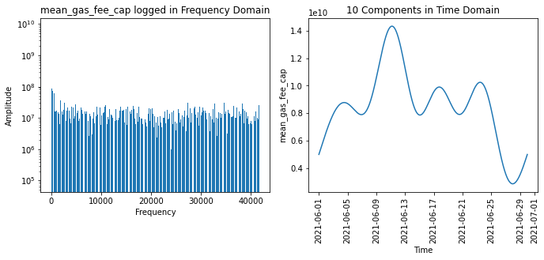

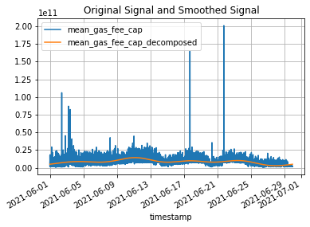

```python
derived_gas_outputs, mean_gas_fee_cap_decomposed = fourier_transform(derived_gas_outputs,'mean_gas_fee_cap',10)
```

```
The maximum price that the message sender is willing to pay per unit of gas
```

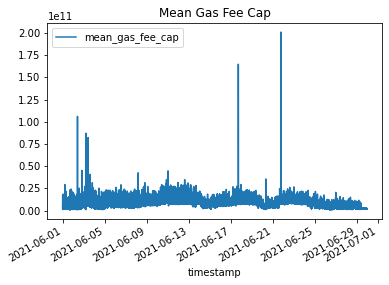

```python
derived_gas_outputs.plot(x='timestamp',y='mean_gas_fee_cap',kind='line',title='Mean Gas Fee Cap')
print('The maximum price that the message sender is willing to pay per unit of gas')
```

```
The price per unit of gas (measured in attoFIL/gas) that the message sender is willing to pay (on top of the BaseFee) to "tip" the miner that will include this message in a block.
```

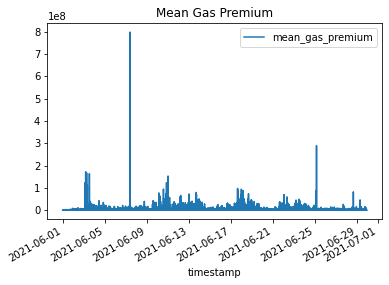

```python
derived_gas_outputs.plot(x='timestamp',y='mean_gas_premium',kind='line',title='Mean Gas Premium')
print('The price per unit of gas (measured in attoFIL/gas) that the message sender is willing to pay (on top of the BaseFee) to "tip" the miner that will include this message in a block.')
```

```
Fourier Transform of mean_gas_premium with 10 components.
```

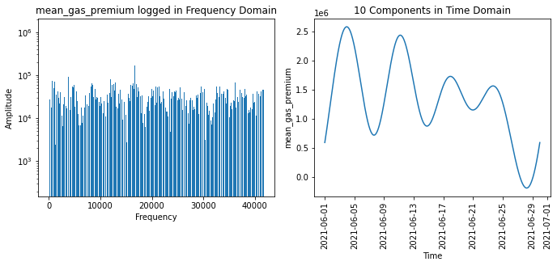

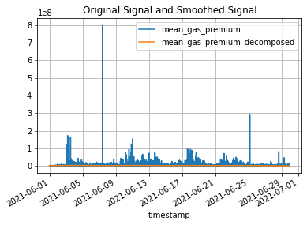

```python
derived_gas_outputs, mean_gas_premium_decomposed  = fourier_transform(derived_gas_outputs,'mean_gas_premium',10)
```

```
A hard limit on the amount of gas (i.e., number of units of gas) that a message’s execution should be allowed to consume on chain. It is measured in units of gas.
```

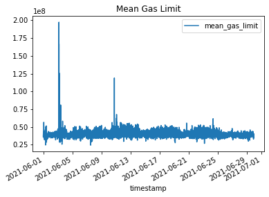

```python
derived_gas_outputs.plot(x='timestamp',y='mean_gas_limit',kind='line',title='Mean Gas Limit')
print('A hard limit on the amount of gas (i.e., number of units of gas) that a message’s execution should be allowed to consume on chain. It is measured in units of gas.')
```

```
Fourier Transform of mean_gas_limit with 10 components.
```

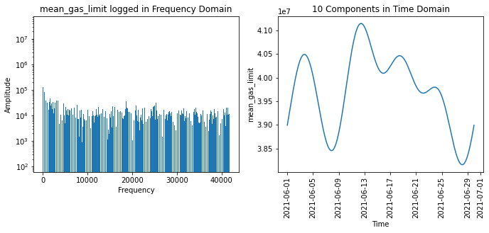

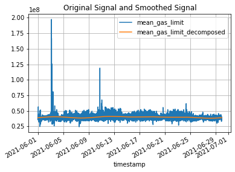

```python
derived_gas_outputs, mean_gas_limit_decomposed = fourier_transform(derived_gas_outputs,'mean_gas_limit',10)
```

```
A measure of the amount of resources (or units of gas) consumed, in order to execute a message.
```

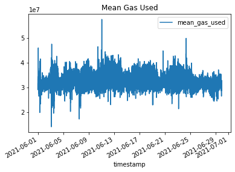

```python
derived_gas_outputs.plot(x='timestamp',y='mean_gas_used',kind='line',title='Mean Gas Used')
print('A measure of the amount of resources (or units of gas) consumed, in order to execute a message.')
```

```
Fourier Transform of mean_gas_used with 10 components.
```

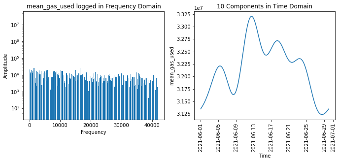

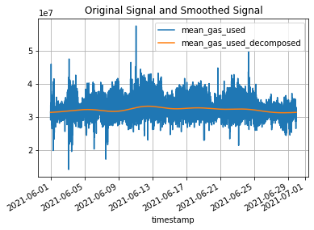

```python
derived_gas_outputs, mean_gas_used_decomposed = fourier_transform(derived_gas_outputs,'mean_gas_used',10)
```

```
he set price per unit of gas (measured in attoFIL/gas unit) to be burned (sent to an unrecoverable address) for every message execution.
```

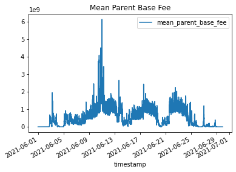

```python
derived_gas_outputs.plot(x='timestamp',y='mean_parent_base_fee',kind='line',title='Mean Parent Base Fee')
print('he set price per unit of gas (measured in attoFIL/gas unit) to be burned (sent to an unrecoverable address) for every message execution.')
```

```
Fourier Transform of mean_parent_base_fee with 10 components.
```

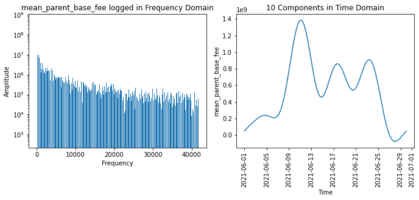

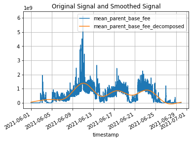

```python
derived_gas_outputs, mean_parent_base_fee_decomposed = fourier_transform(derived_gas_outputs,'mean_parent_base_fee',10)
```

```
he amount of FIL (in attoFIL) to burn as a result of the base fee. It is parent_base_fee (or gas_fee_cap if smaller) multiplied by gas_used. Note: successfull window PoSt messages are not charged this burn.
```

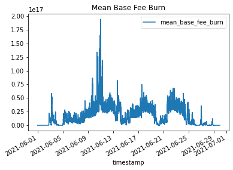

```python
derived_gas_outputs.plot(x='timestamp',y='mean_base_fee_burn',kind='line',title='Mean Base Fee Burn')
print('he amount of FIL (in attoFIL) to burn as a result of the base fee. It is parent_base_fee (or gas_fee_cap if smaller) multiplied by gas_used. Note: successfull window PoSt messages are not charged this burn.')
```

```
Fourier Transform of mean_base_fee_burn with 10 components.
```

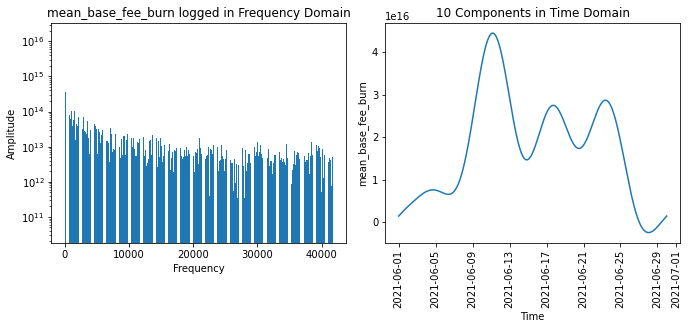

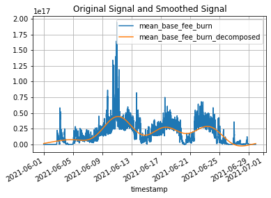

```python
derived_gas_outputs, mean_base_fee_burn_decomposed = fourier_transform(derived_gas_outputs,'mean_base_fee_burn',10)
```

```
The overestimated units of gas to burn. It is a portion of the difference between gas_limit and gas_used.
```

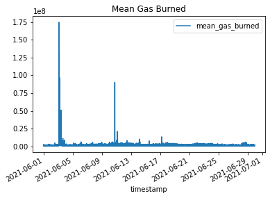

```python
derived_gas_outputs.plot(x='timestamp',y='mean_gas_burned',kind='line',title='Mean Gas Burned')
print('The overestimated units of gas to burn. It is a portion of the difference between gas_limit and gas_used.')
```

```
Fourier Transform of mean_gas_burned with 10 components.
```

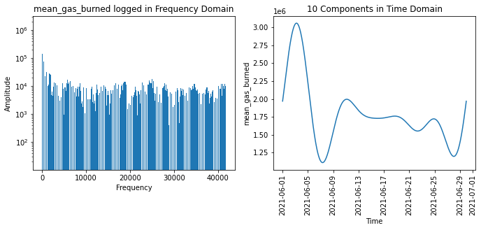

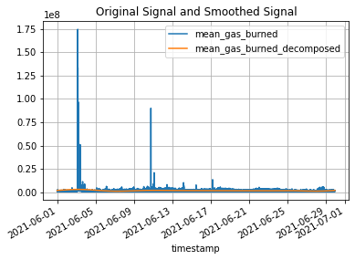

```python
derived_gas_outputs, mean_gas_burned_decomposed = fourier_transform(derived_gas_outputs,'mean_gas_burned',10)
```

```
Fourier Transform of mean_over_estimation_burn with 10 components.
```

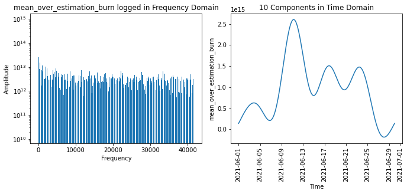

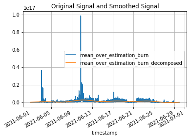

```python
derived_gas_outputs, mean_over_estimation_burn_decomposed = fourier_transform(derived_gas_outputs,'mean_over_estimation_burn',10)
```

```
Fourier Transform of mean_gas_refund with 10 components.
```

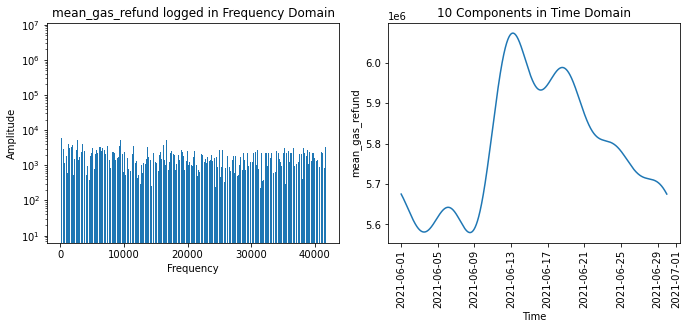

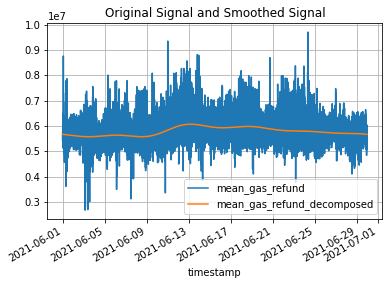

```python
derived_gas_outputs, mean_gas_refund_decomposed = fourier_transform(derived_gas_outputs,'mean_gas_refund',10)
```

```python
derived_gas_outputs.query('mean_gas_burned > 4000000')
```

|  | timestamp | mean_gas_fee_cap | mean_gas_premium | mean_gas_limit | mean_gas_used | mean_parent_base_fee | mean_base_fee_burn | mean_over_estimation_burn | mean_gas_refund | mean_gas_burned | mean_gas_fee_cap_decomposed | mean_gas_premium_decomposed | mean_gas_limit_decomposed | mean_gas_used_decomposed | mean_parent_base_fee_decomposed | mean_base_fee_burn_decomposed | mean_gas_burned_decomposed | mean_over_estimation_burn_decomposed | mean_gas_refund_decomposed |
| --- | --- | --- | --- | --- | --- | --- | --- | --- | --- | --- | --- | --- | --- | --- | --- | --- | --- | --- | --- |
| 2236 | 2021-06-02 13:17:00+00:00 | 6.880334e+09 | 1.028916e+05 | 4.379041e+07 | 3.303338e+07 | 5.892028e+04 | 1.910384e+12 | 2.849939e+11 | 5.908677e+06 | 4.848352e+06 | 7.394618e+09-3.328597e+08j | 1.968436e+06+1.503250e+04j | 4.016501e+07-9.817112e+04j | 3.162625e+07-1.379628e+05j | 1.527365e+08-4.283727e+07j | 4.789688e+15-1.461539e+15j | 2.937958e+06+7.888874e+04j | 4.969613e+14-6.890039e+13j | 5.600810e+06-3.909709e+04j |
| 3039 | 2021-06-03 02:40:00+00:00 | 6.216043e+09 | 1.086384e+05 | 3.943075e+07 | 2.905696e+07 | 2.320815e+08 | 6.618230e+15 | 1.230400e+15 | 5.070770e+06 | 5.303028e+06 | 8.045598e+09+6.761111e+07j | 2.343323e+06+8.486203e+04j | 4.040886e+07-8.242652e+04j | 3.176705e+07-6.666149e+04j | 1.856327e+08+2.930799e+07j | 5.854399e+15+8.567352e+14j | 3.057075e+06+1.253799e+04j | 5.817623e+14+5.007173e+13j | 5.584741e+06-2.830302e+04j |
| 3040 | 2021-06-03 02:41:00+00:00 | 7.759289e+09 | 1.063103e+05 | 3.819974e+07 | 2.917434e+07 | 2.242377e+08 | 6.481789e+15 | 9.452613e+14 | 4.851530e+06 | 4.173869e+06 | 8.046298e+09+6.812564e+07j | 2.343695e+06+8.493460e+04j | 4.040907e+07-8.238632e+04j | 3.176723e+07-6.655141e+04j | 1.856717e+08+2.939666e+07j | 5.855668e+15+8.596045e+14j | 3.057109e+06+1.244717e+04j | 5.818439e+14+5.021755e+13j | 5.584728e+06-2.828208e+04j |
| 3041 | 2021-06-03 02:42:00+00:00 | 6.149556e+09 | 5.103965e+06 | 4.105038e+07 | 2.960600e+07 | 2.280098e+08 | 6.650433e+15 | 1.428333e+15 | 5.200284e+06 | 6.244093e+06 | 8.046998e+09+6.864013e+07j | 2.344066e+06+8.500712e+04j | 4.040928e+07-8.234608e+04j | 3.176742e+07-6.644129e+04j | 1.857106e+08+2.948532e+07j | 5.856936e+15+8.624733e+14j | 3.057142e+06+1.235634e+04j | 5.819255e+14+5.036334e+13j | 5.584716e+06-2.826113e+04j |
| 3042 | 2021-06-03 02:43:00+00:00 | 4.483476e+09 | 5.208213e+06 | 3.972884e+07 | 3.054804e+07 | 2.446428e+08 | 7.372305e+15 | 9.584429e+14 | 5.137952e+06 | 4.042844e+06 | 8.047698e+09+6.915459e+07j | 2.344438e+06+8.507959e+04j | 4.040948e+07-8.230578e+04j | 3.176760e+07-6.633113e+04j | 1.857496e+08+2.957396e+07j | 5.858205e+15+8.653417e+14j | 3.057175e+06+1.226551e+04j | 5.820071e+14+5.050910e+13j | 5.584704e+06-2.824015e+04j |
| ... | ... | ... | ... | ... | ... | ... | ... | ... | ... | ... | ... | ... | ... | ... | ... | ... | ... | ... | ... |
| 40036 | 2021-06-28 19:20:00+00:00 | 3.895368e+09 | 1.036406e+05 | 3.353871e+07 | 2.438100e+07 | 9.208987e+07 | 2.177260e+15 | 4.481456e+14 | 4.334035e+06 | 4.823676e+06 | 3.306311e+09+2.298777e+08j | -1.076618e+05-3.573204e+04j | 3.826904e+07+9.731593e+04j | 3.124257e+07+1.225814e+05j | -4.698576e+07+2.364208e+07j | -1.545628e+15+8.479236e+14j | 1.318906e+06-6.271755e+04j | -1.225238e+14+3.718095e+13j | 5.707558e+06+3.745210e+04j |
| 40041 | 2021-06-28 19:25:00+00:00 | 7.125505e+09 | 2.357576e+05 | 3.829947e+07 | 2.887418e+07 | 1.518404e+08 | 4.286679e+15 | 6.463920e+14 | 5.194119e+06 | 4.231175e+06 | 3.309859e+09+2.274398e+08j | -1.066158e+05-3.619609e+04j | 3.827025e+07+9.726542e+04j | 3.124271e+07+1.221893e+05j | -4.675369e+07+2.319375e+07j | -1.538308e+15+8.335624e+14j | 1.320029e+06-6.232627e+04j | -1.219731e+14+3.644069e+13j | 5.707516e+06+3.740244e+04j |
| 40050 | 2021-06-28 19:34:00+00:00 | 6.195647e+09 | 1.016941e+05 | 3.723291e+07 | 2.779434e+07 | 2.200852e+08 | 6.019152e+15 | 9.346961e+14 | 5.188579e+06 | 4.249998e+06 | 3.316272e+09+2.230433e+08j | -1.047172e+05-3.703008e+04j | 3.827245e+07+9.717103e+04j | 3.124295e+07+1.214791e+05j | -4.633449e+07+2.238592e+07j | -1.525085e+15+8.076827e+14j | 1.322064e+06-6.161974e+04j | -1.209772e+14+3.510693e+13j | 5.707439e+06+3.731171e+04j |
| 40051 | 2021-06-28 19:35:00+00:00 | 6.146174e+09 | 1.080770e+05 | 3.612844e+07 | 2.686453e+07 | 2.174846e+08 | 5.761894e+15 | 9.562606e+14 | 4.819727e+06 | 4.444183e+06 | 3.316987e+09+2.225541e+08j | -1.045049e+05-3.712264e+04j | 3.827270e+07+9.716027e+04j | 3.124298e+07+1.213998e+05j | -4.628780e+07+2.229610e+07j | -1.523613e+15+8.048048e+14j | 1.322291e+06-6.154107e+04j | -1.208662e+14+3.495864e+13j | 5.707430e+06+3.730153e+04j |
| 40066 | 2021-06-28 19:50:00+00:00 | 5.917843e+09 | 2.308893e+05 | 3.503719e+07 | 2.506527e+07 | 3.522965e+08 | 8.664560e+15 | 1.957967e+15 | 4.410808e+06 | 5.561113e+06 | 3.327764e+09+2.152022e+08j | -1.012918e+05-3.850850e+04j | 3.827642e+07+9.699222e+04j | 3.124340e+07+1.202028e+05j | -4.558465e+07+2.094728e+07j | -1.501432e+15+7.615836e+14j | 1.325723e+06-6.035674e+04j | -1.191918e+14+3.273187e+13j | 5.707299e+06+3.714621e+04j |

496 rows × 19 columns

### Messages calculation mapping

Based on the message cost calculation outliend by Filecoin's official documentation, we will map the data obtained to this calculation.

Filecoin: `message_cost_calculation = GasUsage * BaseFee FIL (burned) + GasLimit * GasPremium FIL (miner reward) + OverEstimationBurn * BaseFee FIL`

```python
# create field
derived_gas_outputs['mean_message_cost'] = derived_gas_outputs.mean_gas_used * derived_gas_outputs.mean_base_fee_burn + derived_gas_outputs.mean_gas_limit * derived_gas_outputs.mean_gas_premium + derived_gas_outputs.mean_over_estimation_burn * derived_gas_outputs.mean_base_fee_burn
```

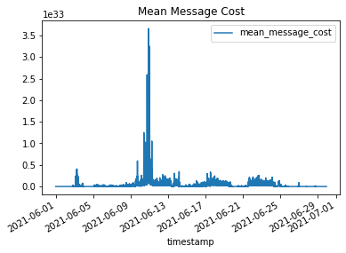

```python
derived_gas_outputs.plot(x='timestamp',y='mean_message_cost',kind='line',title='Mean Message Cost')
```

```
Fourier Transform of mean_message_cost with 10 components.
```

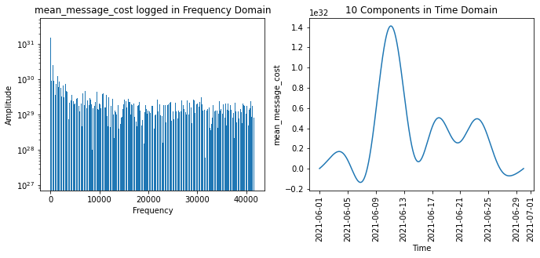

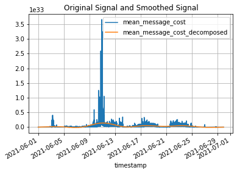

```python
derived_gas_outputs, mean_message_cost_decomposed = fourier_transform(derived_gas_outputs,'mean_message_cost',10)
```